# PA1_template.Rmd

Cesar O. Flores Garcia

10/19/2014

### Loading Data

First we need to load the data. The data need to be only loaded a single time:

```r
library(data.table)
zip_file  <- "activity.zip"
text_file <- "activity.csv"
colClasses <- c("numeric","Date","integer")
df_activity <- read.csv(unz(zip_file, text_file), header = TRUE, sep = ",", colClasses=colClasses,na.strings="NA")
dt_activity <- as.data.table(df_activity)
```

### Number of Steps by day

The next plot shows the histogram of steps. NA values are ignored, and the number of bins was assigned to 20. Notice that the big amount of days with 0 frequency is due in part to the NA values in some days.

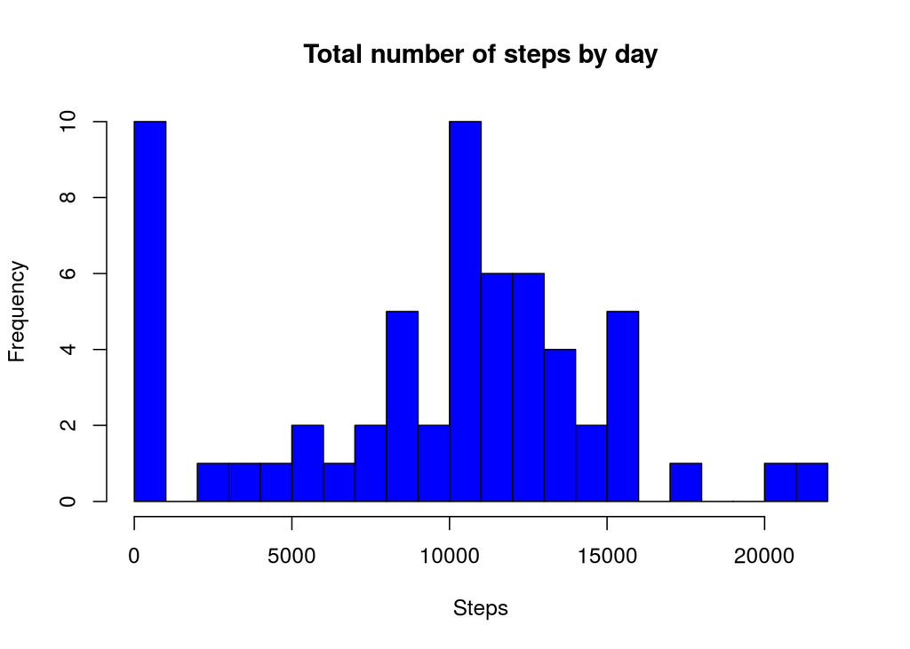

Now, we can calculate both the mean and median using:

```r
mean_steps   <- mean(step_daily_average)
median_steps <- median(step_daily_average)
```

### Average Daily Activity Pattern

The next plot shows the average number of steps by interval, averaged across all days

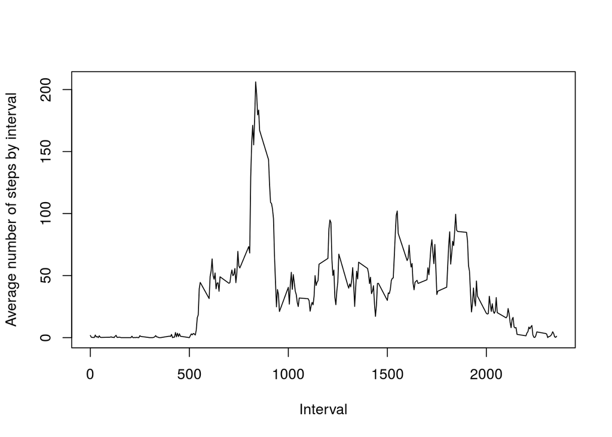

Now, for finding the interval with the maximum number of steps averaged across al days we use:

```r
max_steps_interval   <- max(dt_temp$average_steps)
max_interval <- dt_temp[average_steps==max_steps_interval,interval]
```

The previous code give us that the 5-minutes interval with the highest average number of steps is 835

### Missing Values

First we create a new table were we will fill the step missing values using the mean of the 5-minutes interval.

```r
n_nas <- sum( is.na( dt_activity$steps ) ) #Only steps contain NA's values
dt_activity_fill <- copy(dt_activity)
dt_activity_fill[is.na(steps)]$steps <- with(dt_activity,
                                             ave(steps, interval,
                                                 FUN = function(x) mean(x, na.rm = TRUE)))[is.na(dt_activity_fill$steps)]
```

The numer of NA’s values is 2304: Now, we can repeat the process, for calculating the histogram:

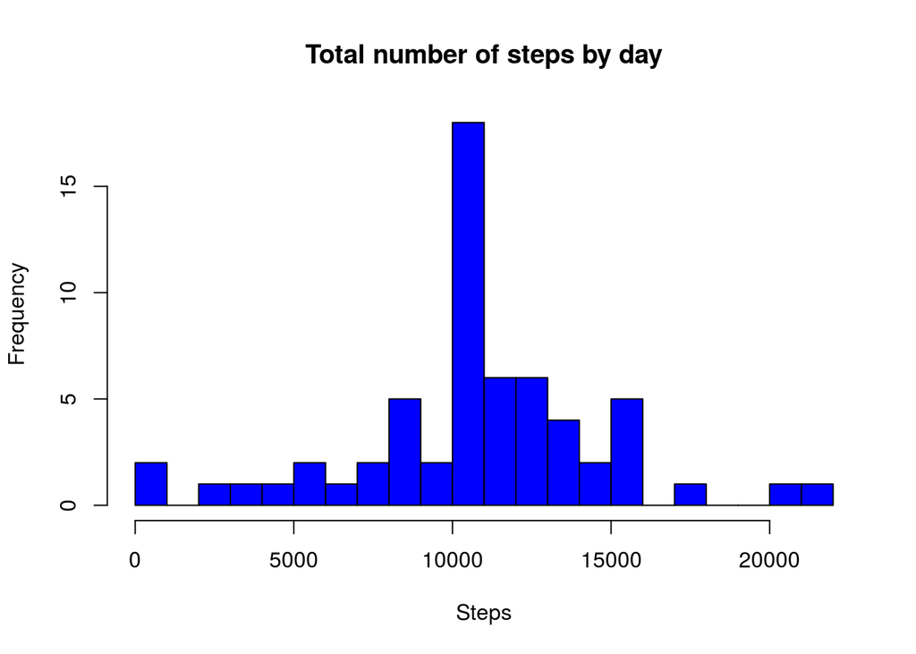

### Weekdays vs Weekends

The next plot will plot the difference between weekends and weekdays

[output not shown]

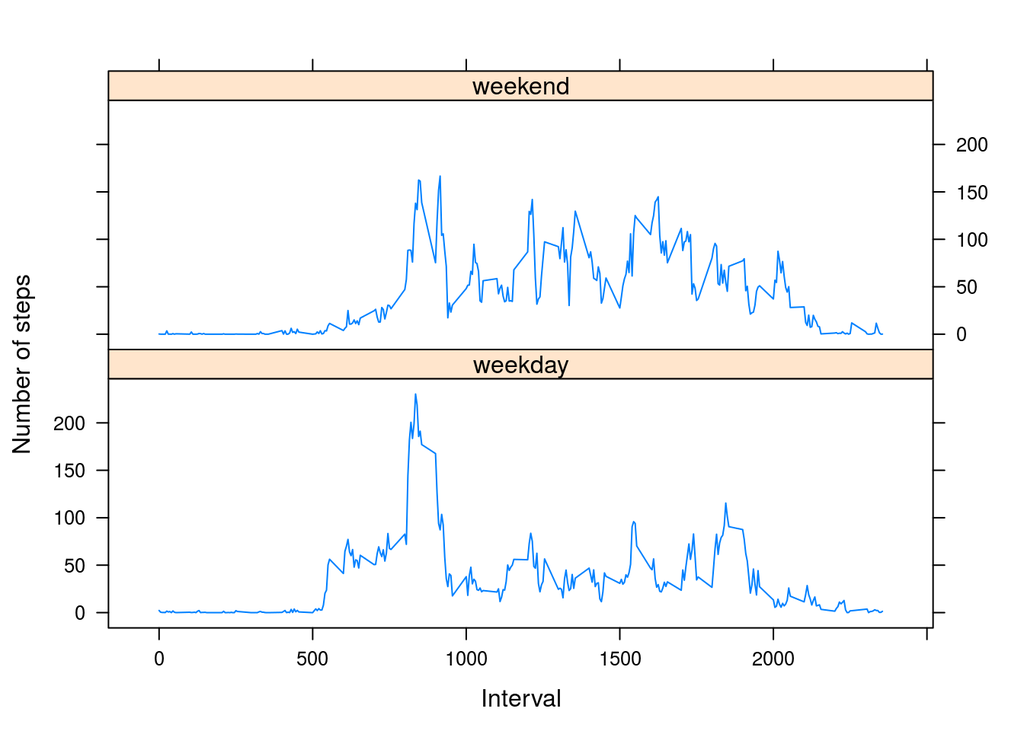

As we can se there appears to exist some difference at the start of the day. This may due to the fact that on weekends, people normally wake up later than on weekdays.